# PA1_template.Rmd

Ramon Chalmeta

18 de octubre de 2015

Loading and preprocessing the data

```r
myData <- read.csv("activity.csv")
```

1. What is mean total number of steps taken per day?

Historgram:

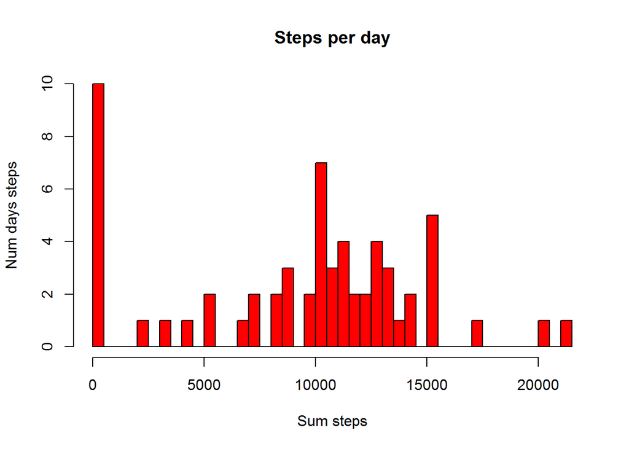

```r
  options(scipen=100)
  diferentDates <- as.vector(unique(myData$date))

  numSteps <- vector("numeric")
  for(index in 1:length(diferentDates))
  {
    currentDate <- diferentDates[index]

    myFilterDataaFrame <- myData[myData$date==currentDate,]
    totalSteps <- sum(myFilterDataaFrame$steps, na.rm = TRUE)
    numSteps <- rbind(numSteps, totalSteps)

  }

  hist(numSteps, breaks=length(diferentDates), main = "Steps per day",col="red",
       xlab = "Sum steps", ylab = "Num days steps")
```

```r
  meanNumSteps <- mean(numSteps)
  medianNumSteps <- median(numSteps)
```

Mean is: 9354.2295082

Median is: 10395

2. What is the average daily activity pattern?

Plot:

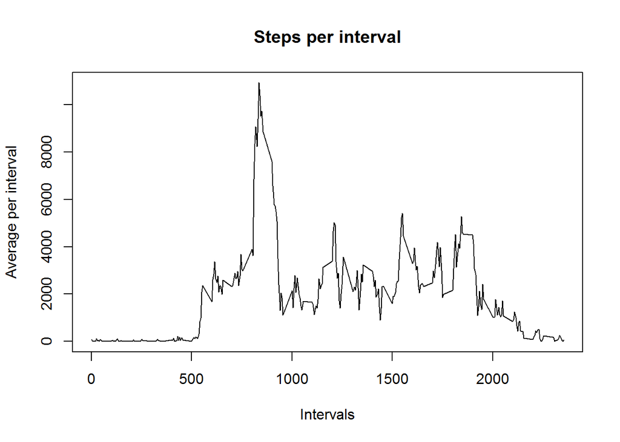

```r
  diferentIntervals <- as.vector(unique(myData$interval))

  numStepsPerInterval <- vector("numeric")
  for(index in 1:length(diferentIntervals))
  {
    currentInterval <- diferentIntervals[index]

    myFilterDataaFrame <- myData[myData$interval==currentInterval,]
    totalStepsPerInterval <- sum(myFilterDataaFrame$steps, na.rm = TRUE)
    numStepsPerInterval <- rbind(numStepsPerInterval, totalStepsPerInterval)
  }
  plot(diferentIntervals, numStepsPerInterval,type = "l",lty=1,
     main = "Steps per interval", xlab = "Intervals", ylab = "Average per interval")
```

```r
  indexMaxInterval <- which.max(numStepsPerInterval)
```

The interval whit maximxum number of steps is: 835-840

3. Imputing missing values

```r
   rowsWithMissValues <- myData[is.na(myData$steps),]
```

The total number of rows with NAs is: 2304

I have created a new dataset where the Na values are replced for the median value/num intervals (calculated in the first question).

```r
  myDataRefined <- myData
  myDataRefined[is.na(myData)] <- medianNumSteps/length(as.vector(unique(myData$interval)))
```

Historgram with data refined:

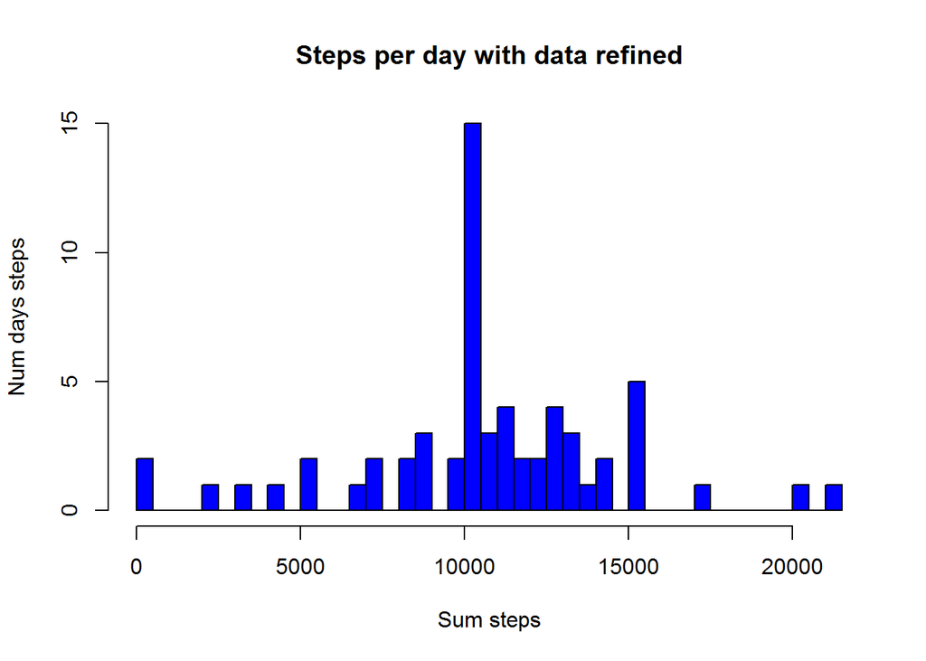

```r
  numStepsRefined <- vector("numeric")
  for(index in 1:length(diferentDates))
  {
    currentDate <- diferentDates[index]

    myFilterDataaFrame <- myDataRefined[myDataRefined$date==currentDate,]
    totalStepsRefined <- sum(myFilterDataaFrame$steps, na.rm = TRUE)
    numStepsRefined <- rbind(numStepsRefined, totalStepsRefined)

  }

  hist(numStepsRefined, breaks=length(diferentDates), main = "Steps per day with data refined",
       col="blue",  xlab = "Sum steps", ylab = "Num days steps")
```

```r
  meanNumStepsRefined <- mean(numStepsRefined)
  medianNumStepsRefined <- median(numStepsRefined)
```

Mean with refined data is: 10717.5081967

Median with refined data is: 10395

1. Do these values differ from the estimates from the first part of the assignment?

2. What is the impact of imputing missing data on the estimates of the total daily number of steps?

4. Are there differences in activity patterns between weekdays and weekends?

Add new column with factor weekday or weekend.

```r
  weekDaymyDataRefined <- grepl("sábado|domingo",weekdays(as.Date(myDataRefined[,2])))
  myDataRefined$weekend <- weekDaymyDataRefined

  myDataRefined$weekend[myDataRefined$weekend==TRUE] <- "weekend"
  myDataRefined$weekend[myDataRefined$weekend==FALSE] <- "weekday"
```

Plot weekdays/weekend:

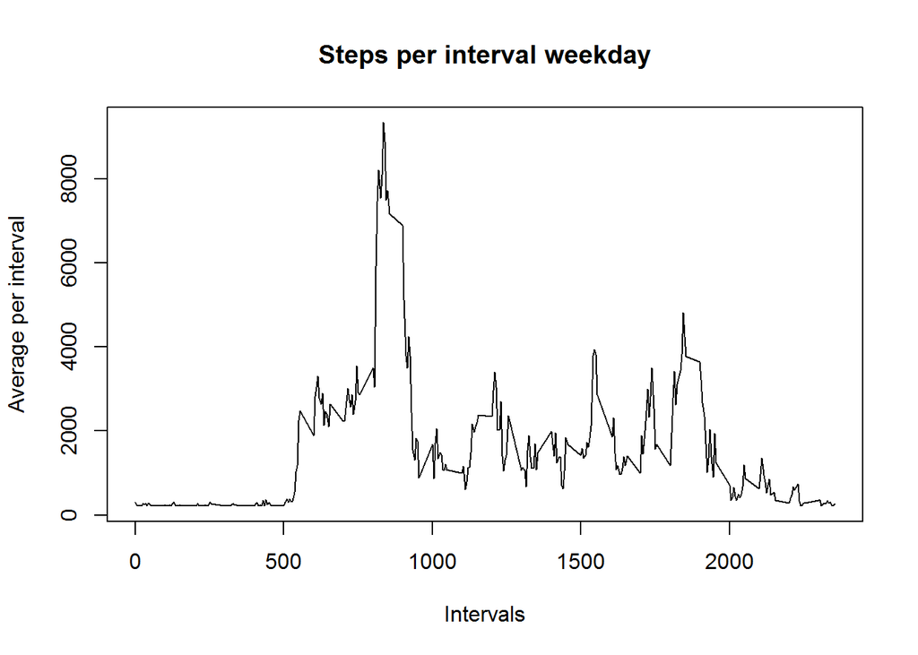

```r
  numStepsPerIntervalWeekend <- vector("numeric")
  numStepsPerIntervalWeekday <- vector("numeric")
  for(index in 1:length(diferentIntervals))
  {
    currentInterval <- diferentIntervals[index]

    myFilterDataaFrame <- myDataRefined[myDataRefined$interval==currentInterval,]

    totalStepsPerIntervalWeekend <- sum(myFilterDataaFrame$steps[myFilterDataaFrame$weekend=="weekend"], na.rm = TRUE)

    totalStepsPerIntervalWeekday <- sum(myFilterDataaFrame$steps[myFilterDataaFrame$weekend=="weekday"], na.rm = TRUE)

    numStepsPerIntervalWeekend <- rbind(numStepsPerIntervalWeekend, totalStepsPerIntervalWeekend)

    numStepsPerIntervalWeekday <- rbind(numStepsPerIntervalWeekday, totalStepsPerIntervalWeekday)
  }


  plot(diferentIntervals, numStepsPerIntervalWeekday,type = "l",lty=1,
     main = "Steps per interval weekday", xlab = "Intervals", ylab = "Average per interval")
```

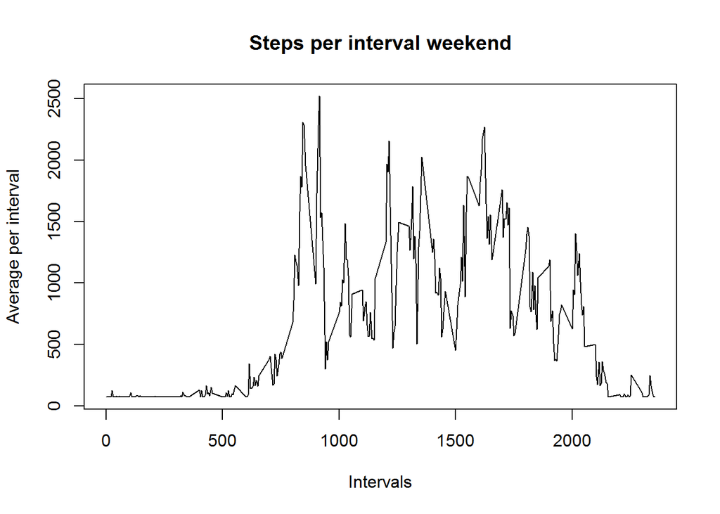

```r
  #lines(diferentIntervals, numStepsPerIntervalWeekend,type = "l")


   plot(diferentIntervals, numStepsPerIntervalWeekend,type = "l",lty=1,
    main = "Steps per interval weekend", xlab = "Intervals", ylab = "Average per interval")
```

```r
   #axis(4, ylim=c(0,7000), col="red",col.axis="red",las=1)
```